# Comparing States

**Comparing the Three States**

The three states share a substantial connection between agricultural land and livestock, but the crops, animals, and markets behind that connection differ. Comparing like measures reveals those differences more clearly than a single acreage ranking.

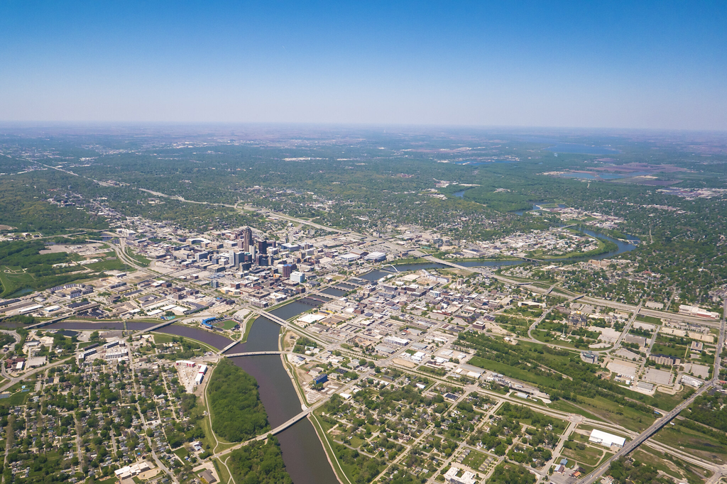

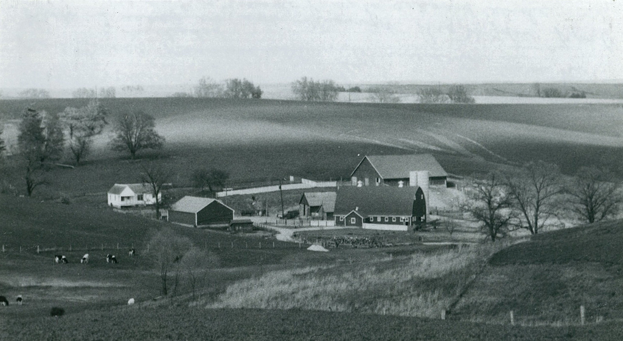

*Landscape Context and Comparable Measures*

*Crop Mix and Feed Allocation*

*Livestock Systems*

*County Relationships and Feed Markets*

*Farm Structure and Land Transitions*

*Geography Within States*

*Comparing Estimates*

*Comparable Indicators and Project Estimates*

The table to the right presents comparable Census and NASS indicators

This table presents the feed estimates and 2017 grazing baseline, with the method for each state identified

The footprint estimates combine different source years. New York uses an aggregate Census-based feed category; Iowa and Minnesota use crop-by-crop allocations. Adding feed and grazing assumes the components do not overlap. Grazing includes grassland pasture and range, cropland pasture, and grazed forest. Cropland pasture must be subtracted if total cropland and grazing are combined.

The estimated footprint occupies about 16% of New York’s land, 33% of Minnesota’s, and 57% of Iowa’s. Part of this difference reflects the wider landscape: agriculture occupies a much smaller share of forested New York than of Iowa’s former prairie. The different feed-estimation methods also affect the comparison. The totals show statewide scale; comparable crop and livestock statistics explain more about the systems involved.

Using the same 2022 Census measure, total cropland covers about 4.08 million acres in New York, 21.54 million in Minnesota, and 25.88 million in Iowa. The 2024 harvested corn figures show an equally clear contrast: silage accounts for about 45%, 5%, and 3%, respectively. New York’s corn therefore has a much more direct forage role, while the larger grain areas in Iowa and Minnesota connect livestock with food, fuel, and export markets.

Milk cows make up about 86% of the combined milk-and-beef-cow inventory in New York and 56% in Minnesota. In Iowa, beef cows account for about 77%. Those January 1, 2025 figures help explain the different forage patterns. Iowa’s and Minnesota’s large hog and poultry sectors add demand for grain and protein meal that a cow-only comparison does not capture.

Dairy cows and corn silage occur together at the county scale in all three states. Iowa’s weaker hog-grain association shows the limits of relying on proximity to understand feed supply. A weak local relationship can coexist with large feed demand when crops serve several markets and feed travels between regions. County maps show concentrations of animals and crops; purchasing and shipment records are needed to connect them.

Farm numbers fell in all three states between 2002 and 2022, but average size did not rise everywhere. Minnesota’s farm count declined about 19% while its average grew from 340 to 388 acres. New York’s count fell 17.7%, with average size rising modestly from 206 to 212 acres. Iowa’s count fell about 4%, while its average fell slightly from 350 to 345 acres, even as the number of very large farms increased. The changes show different patterns of farm organization rather than a uniform increase in production intensity.

Each state also contains distinct agricultural regions. Iowa’s dairy-silage clusters sit within a much larger grain system; Minnesota’s crop and livestock regions differ from its forested north; New York’s farms occupy part of a predominantly forested landscape. Decisions about nutrient management, community protection, or restoration need that local detail alongside statewide acreage.

The most reliable comparisons use the same measure and year. New York’s feed estimate cannot be treated as directly equivalent to the fractional crop allocations for Iowa and Minnesota, and a share of total state land answers a different question from a share of farmland. Tables 3 and 4 keep comparable agricultural statistics separate from the project estimates.

The following tables summarize measures across states. Rounded totals may differ from sums of rounded components

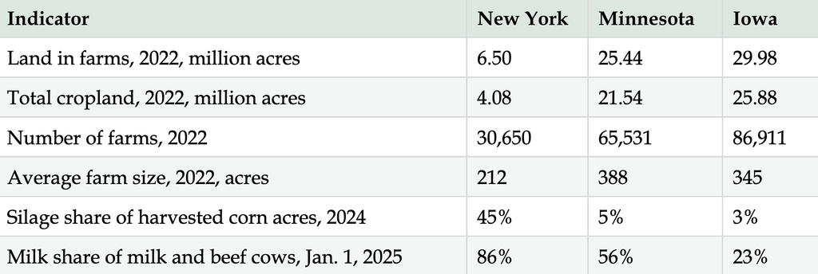

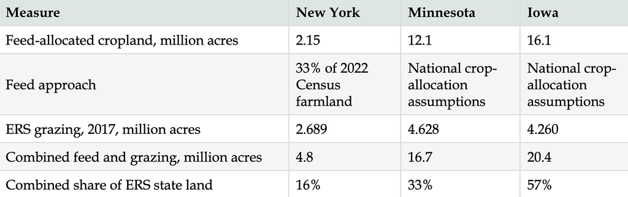

**What the Comparison Shows**

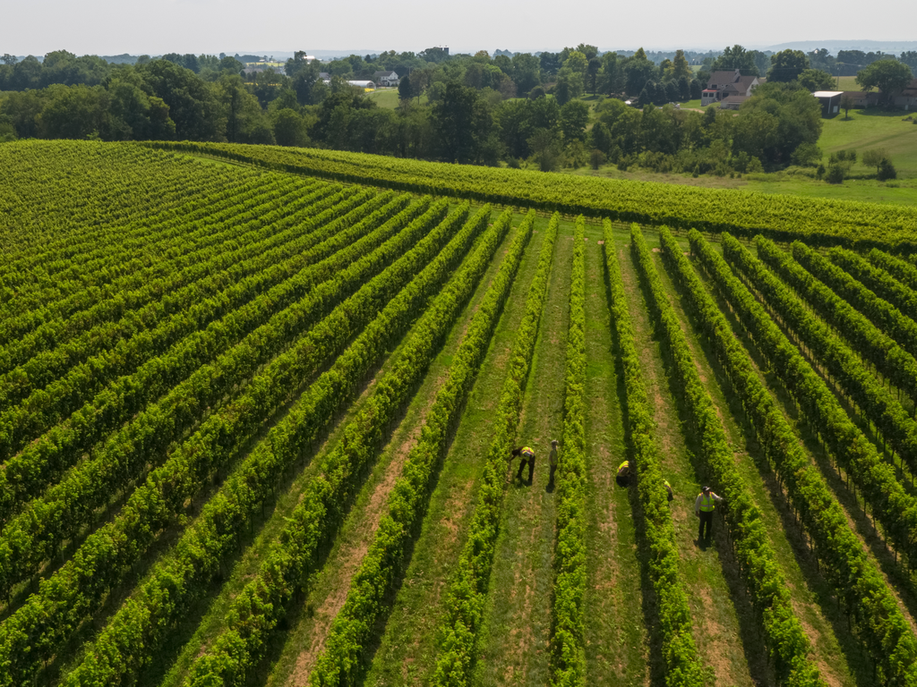

*Feed Extends the Land Footprint*

*Feed and Fuel Share the Same Crops*

*Land Area and Environmental Effects*

*Choices for Agricultural Land*

*Climate Benefits Depend on the Alternative*

Animal agriculture’s land use extends from the fields where forage is harvested to the grain and oilseed regions supplying feed markets. Counting livestock sites and pasture alone misses much of that land. Hoofprint connects these uses while showing why local forage relationships are easier to see on county maps than the trade supporting grain-fed animals.

Ethanol and soybean processing link feed and fuel rather than divide them cleanly. Distillers grains, meal, and hulls supply animals even when other products from the same crop enter fuel or food markets. Land accounting must divide acreage consistently among those outputs. Predicting how acreage would change with feed or fuel demand is a separate economic question.

A pasture, a fertilized corn field, and a drained wetland used for crops can occupy the same area while having very different effects on carbon, water, and habitat. Similarly, a livestock facility may occupy little land but create concentrated pollution near homes. Acreage establishes scale; location and management determine many of the consequences.

The extent of feed production raises questions about what else that land could support. Soil, climate, drainage, farm income, tenure, infrastructure, and markets shape the available choices. Changes in demand also matter: restoring a field while shifting its production elsewhere can reduce or offset the intended benefit.

Restoration options vary within and among states. Forest recovery may suit some New York fields, while prairie or wetland restoration may suit some Iowa and Minnesota sites. Other land may be better suited to food crops, perennial production, or existing habitat. Comparing defined alternatives over a common time period is more informative than applying one sequestration rate to every feed acre (IPCC, 2019; Hayek et al., 2021).

**Policy and Research Priorities**

[figure not shown]

*Feed Supply Chain Transparency*

*Integrating Land Use into Climate Planning*

*Measuring Carbon Opportunity Costs*

*Diversification of Cropping Systems*

*Policies Matched to Livestock Systems*

Crop production, feed processing, and livestock operations are reported separately, making it difficult to follow feed from field to animal. Consistent reporting of major feed ingredients, quantities, and sourcing regions would help connect those records. States could begin with large livestock operations, feed mills, and processors, using existing purchasing data where possible and protecting confidential business information. Regional summaries should distinguish locally grown feed from imports and exports.

Feed production belongs in an assessment of livestock’s climate footprint. States can use feed-allocation estimates to connect crop-production emissions with the animals those crops support, while reconciling the results with existing greenhouse gas inventories to avoid double counting. Land-use scenarios can then compare continued production, changes in management, and restoration. Potential carbon gains from those alternatives should be reported separately from current emissions and removals.

A useful comparison would account for existing soil carbon, vegetation and management, the time needed to accumulate carbon, and the durability of any gain. It would also examine whether displaced production moves elsewhere. Avoided fertilizer or manure emissions should be calculated separately from additional carbon storage, with habitat, water quality, and farm income considered alongside climate benefits.

Support farmers who want to diversify through technical assistance, crop trials, transition funding, and markets for alternative products. Longer rotations, perennial crops, and crops grown for human food can broaden the options available to farms where soils, climate, processing capacity, and demand support them. Programs should assess effects on farm income, emissions, water quality, habitat, and total land demand.

Policies should reflect the livestock systems they address. Dairy regions need attention to forage sourcing and manure management; hog and poultry systems require better visibility into grain and protein-meal supply chains. Cattle feeding also connects grain and forage markets with earlier grazing stages. Changes in feeding or grazing should be assessed for their full effects on land demand, emissions, animal welfare, and neighboring communities.

**Conclusion**

Animal agriculture shapes land well beyond the boundaries of livestock farms. New York’s dairy and forage systems, Minnesota’s diversified crop and livestock economy, and Iowa’s extensive grain production show different forms of that connection. Their estimated footprints bring feed fields into the picture alongside grazing land, while the county comparisons reveal why some relationships are locally visible and others depend on trade.

Understanding those connections gives policymakers and farmers a better basis for decisions about agricultural land. Feed-sourcing records can clarify where livestock demand is met; local land and management data can identify environmental pressures and feasible alternatives. Together, they can help evaluate continued production, crop diversification, and restoration in terms of their consequences for farms, climate, water, habitat, and communities.

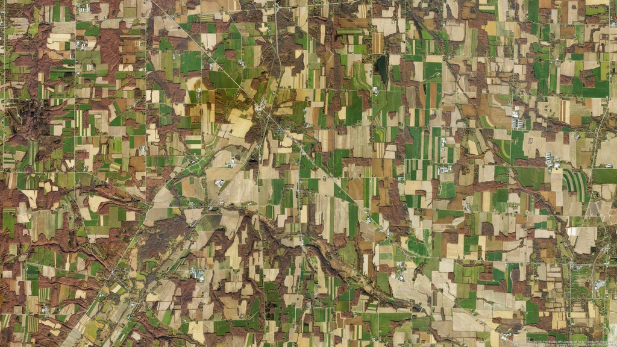

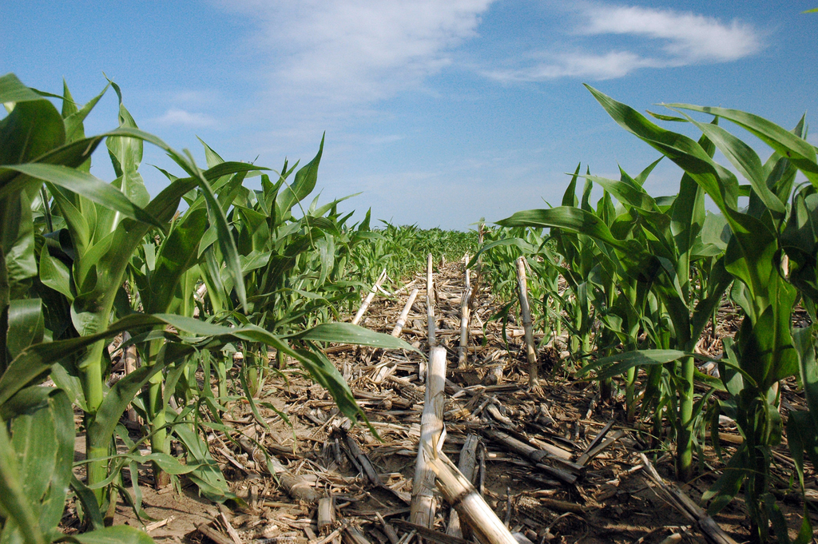

[figure not shown]